# R Notebook

```r
library(tidyverse)
library(CodeClanData)
library(gghighlight)
```

# 1. Load in the libraries you need, and look at the backpack data. Take note of variable names and dimensions.

```r
backpack
```

| backpack_weight | body_weight | ratio | back_problems | major | year | sex | status | units |
| --- | --- | --- | --- | --- | --- | --- | --- | --- |
| 9 | 125 | 0.0720000 | 1 | Bio | 3 | Female | U | 13 |
| 8 | 195 | 0.0410256 | 0 | Philosophy | 5 | Male | U | 12 |
| 10 | 120 | 0.0833333 | 1 | GRC | 4 | Female | U | 14 |
| 6 | 155 | 0.0387097 | 0 | CSC | 6 | Male | G | 0 |
| 8 | 180 | 0.0444444 | 0 | EE | 2 | Female | U | 14 |
| 5 | 240 | 0.0208333 | 0 | History | 0 | Male | G | 0 |
| 8 | 170 | 0.0470588 | 0 | CM | 3 | Male | U | 15 |
| 4 | 185 | 0.0216216 | 1 | ARCE | 5 | Female | U | 18 |
| 5 | 130 | 0.0384615 | 0 | Bio | 4 | Female | U | 14 |
| 2 | 120 | 0.0166667 | 0 | Bio | 5 | Female | U | 8 |

[output cut: 90 more lines]

# 2. What is the distribution of backpack weights that students are carrying? Choose an appropriate graph to show the distribution.

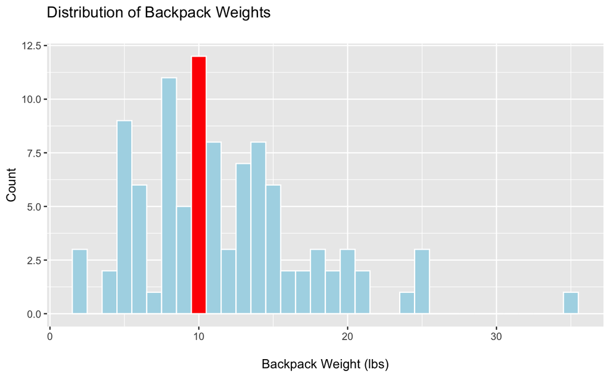

```r
backpack %>%
  ggplot(aes(x = backpack_weight,
             fill = backpack_weight == 10)) +
  geom_histogram(binwidth = 1, col = "white") +
  scale_fill_manual(values = c("lightblue", "red"), guide = "none") +
  labs(x = "\nBackpack Weight (lbs)",
       y = "Count",
       title = "Distribution of Backpack Weights\n")
```

# 3. Are there differences in backpack weight between sex?

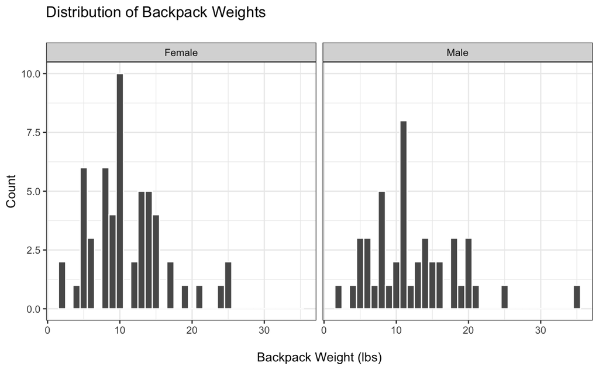

```r
backpack %>%
  ggplot(aes(x = backpack_weight,
             fill = backpack_weight)) +
  geom_histogram(binwidth = 1, col = "white") +
  facet_wrap(~ sex) +
  labs(x = "\nBackpack Weight (lbs)",
       y = "Count",
       title = "Distribution of Backpack Weights\n") +
  theme_bw()
```

The histogram from question 3 was faceted to show the distribution between males and females It can be see that the most common weight overall of 10lbs is the most common weight for females Interestingly, there are only 2 males whose backpacks were this weight. Instead the most common weight was 11lbs

# 4. What is the relationship between body weight and backpack weight?

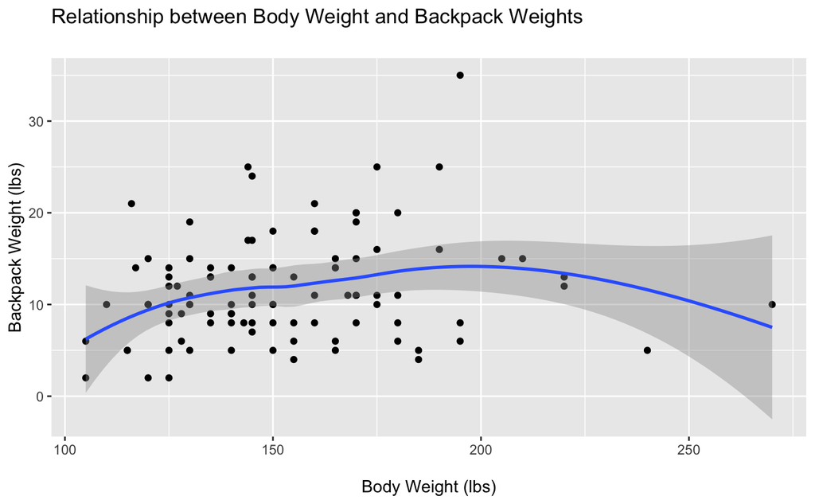

```r
backpack %>%
  ggplot(aes(x = body_weight,
             y = backpack_weight)) +
  geom_point() +
  geom_smooth() +
    labs(x = "\nBody Weight (lbs)",
       y = "Backpack Weight (lbs)",
       title = "Relationship between Body Weight and Backpack Weights\n")
```

# 5. Is this relationship different between men and women? Choose an appropriate plot and interpret your findings.

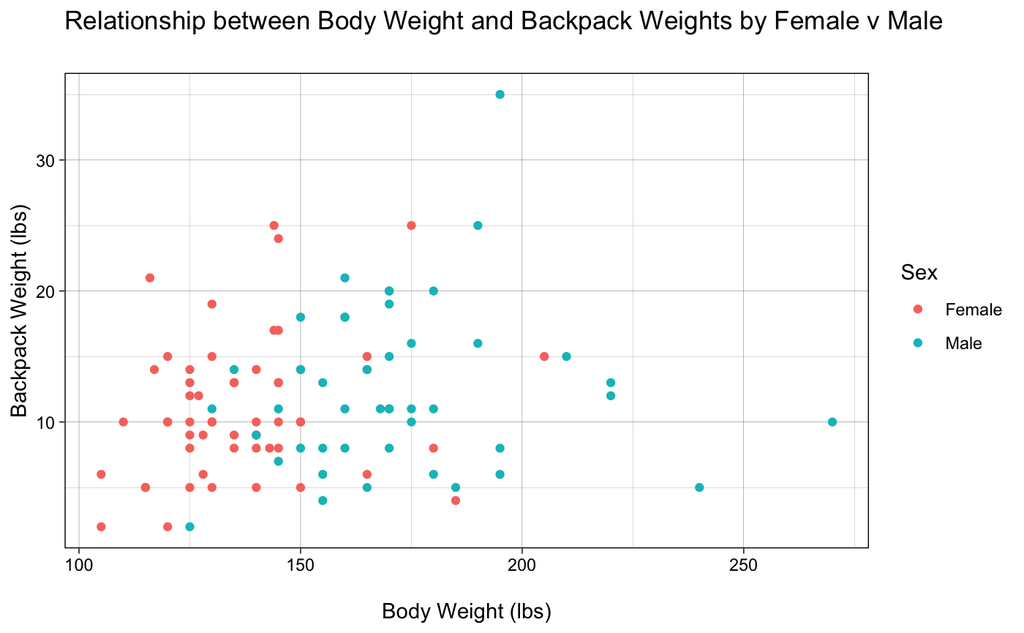

```r
backpack %>%
  ggplot(aes(x = body_weight,
             y = backpack_weight)) +
  geom_point(aes(colour = sex)) +
   labs(x = "\nBody Weight (lbs)",
       y = "Backpack Weight (lbs)",
       title = "Relationship between Body Weight and Backpack Weights by Female v Male\n",
       colour = "Sex") +
  theme_linedraw()
```

The scatter plot from Q4 was run again, this time accounting for the sex of the student There is a clear distinction in bodyweight between the Male and Female students Interestingly, the back pack weights that each sex carries is evenly distributed, with 2/3 of the second heaviest backpack weights being carried by females. The heaviest bag, however, is carried by a Male

# 6. What proportion of students report back pain?

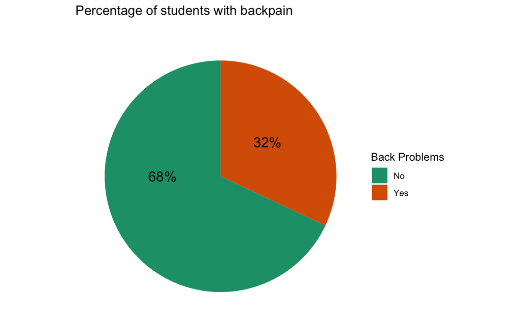

```r
bar_plot_data <- backpack %>%
  mutate(back_problems = as.character(back_problems)) %>%
  mutate(back_problems = recode(back_problems,
                                "1" = "Yes",
                                "0" = "No")) %>%
  mutate(back_problems = as.factor(back_problems)) %>%
  group_by(back_problems) %>%
  summarise(count = n())


bar_plot <- bar_plot_data %>%
  ggplot(aes(x = "",
             y = count,
             fill = back_problems)) +
  geom_bar(width = 1, stat = "identity") +
   labs(x = "",
       y = "Percentage of students",
       title = "Percentage of students with backpain\n",
       fill = "Back Problems")

pie <- bar_plot +
  geom_text(aes(label = paste0(count / sum(count) * 100, "%")), size = 5, y = c(75, 15)) +
  coord_polar(theta = "y", start = 0) +
  scale_fill_brewer(palette = "Dark2") +
  theme_void()
pie
```

A pie chart was created to find the proportion of students that have back pain It can be seen that around 1/3 of students reported back pain

# 7. Is this proportion different between men and women?

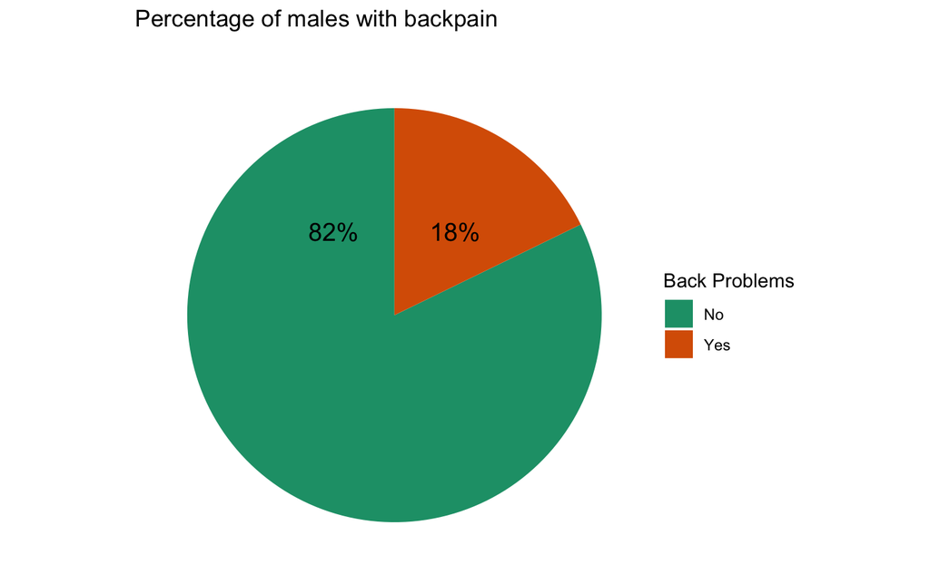

```r
bar_plot_male_data <- backpack %>%
  filter(sex == "Male") %>%
  mutate(back_problems = as.character(back_problems)) %>%
  mutate(back_problems = recode(back_problems,
                                "1" = "Yes",
                                "0" = "No")) %>%
  mutate(back_problems = as.factor(back_problems)) %>%
  group_by(back_problems) %>%
  summarise(count = n()) %>%
  mutate(across(.cols = where(is.numeric), .fns = ~count/45 * 100))

bar_plot_male <- bar_plot_male_data %>%
  ggplot(aes(x = "",
             y = count,
             fill = back_problems)) +
  geom_bar(width = 1, stat = "identity") +
   labs(x = "",
       y = "Percentage of males",
       title = "Percentage of males with backpain\n",
       fill = "Back Problems")


pie_male <- bar_plot_male +
  geom_text(aes(label = paste0(round(count / sum(count) * 100), "%")), size = 5, y = c(90, 10)) +
  coord_polar(theta = "y", start = 0) +
  scale_fill_brewer(palette = "Dark2") +
  theme_void()
pie_male
```

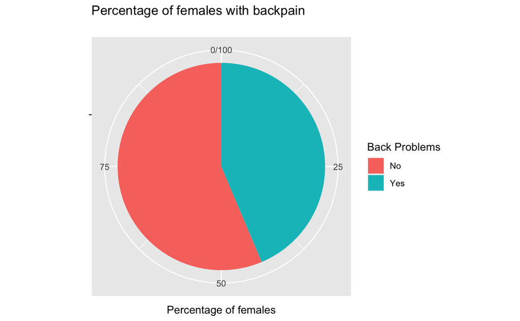

```r
bar_plot_female <- backpack %>%
  filter(sex == "Female") %>%
  mutate(back_problems = as.character(back_problems)) %>%
  mutate(back_problems = recode(back_problems,
                                "1" = "Yes",
                                "0" = "No")) %>%
  mutate(back_problems = as.factor(back_problems)) %>%
  group_by(back_problems) %>%
  summarise(count = n()) %>%
  mutate(across(.cols = where(is.numeric), .fns = ~count/55 * 100)) %>%
  ggplot(aes(x = "",
             y = count,
             fill = back_problems)) +
  geom_bar(width = 1, stat = "identity") +
   labs(x = "",
       y = "Percentage of females",
       title = "Percentage of females with backpain\n",
       fill = "Back Problems")


pie_female <- bar_plot_female +
  coord_polar(theta = "y", start = 0)
pie_female
```

2 more pie charts were created to find the difference in percentage between males and females that reported back pain It can be seen that there is a large disparity between the sexes Less than 25% of Males reported back pain whilst over 40% of Females reported backpain

# 8. Now you’ve investigated your data separately, create plots to describe the relationship between backpack weight, body weight, gender and reported backpain.

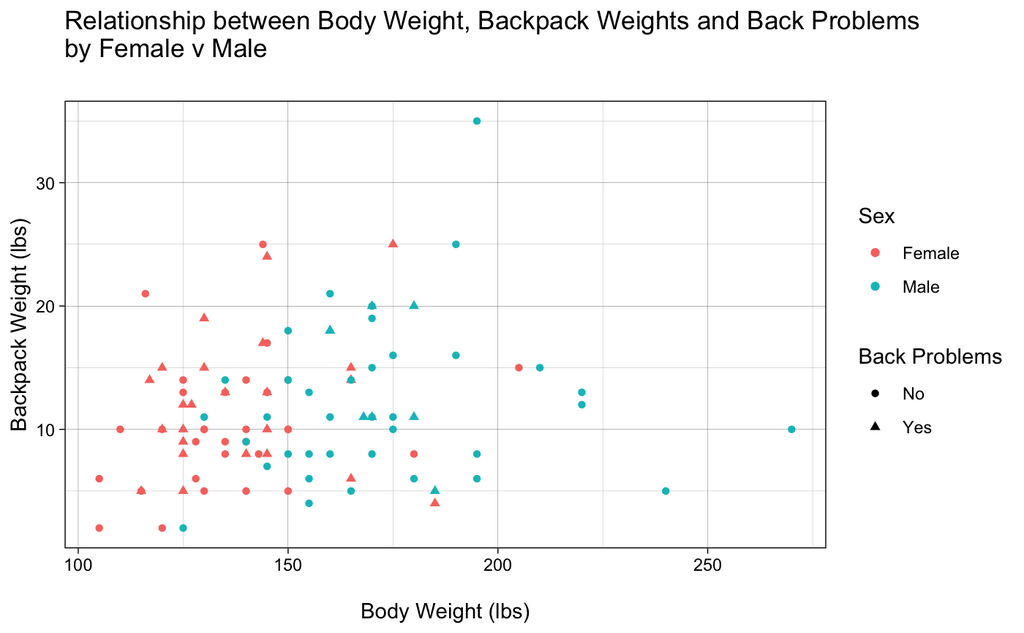

```r
relationship_plot <- backpack %>%
  mutate(back_problems = as.character(back_problems)) %>%
  mutate(back_problems = recode(back_problems,
                                "1" = "Yes",
                                "0" = "No")) %>%
  mutate(back_problems = as.factor(back_problems)) %>%
  ggplot(aes(x = body_weight,
             y = backpack_weight,
             shape = back_problems)) +
  geom_point(aes(colour = sex)) +
   labs(x = "\nBody Weight (lbs)",
       y = "Backpack Weight (lbs)",
       title = "Relationship between Body Weight, Backpack Weights and Back Problems\nby Female v Male\n",
       colour = "Sex",
       shape = "Back Problems") +
  theme_linedraw()

relationship_plot
```

A scatter plot with different shapes and colour was used to plot the correlation between bodyweight, backpack weight, back problems and gender